# Pushups Problem

Katherine Larin

13 March, 2020

# Introduction

$H_0$: There is no difference between the average number of pushups done in two minutes between line and skill players

$H_A$: There is a difference between the average number of pushups done in two minutes between line and skill players.

Commit the .rmd and .html file, push to your github accout, submit the URL once you’ve completed the assignment

```r
players <- pushups
```

Two football players at GC asked their team-mates to do as many pushups as they could in two minutes.

A data frame with 30 observations on the following 3 variables.

*weight*  
weight of subject in pounds.

*pushups*  
number of pushups the player completed in two minutes.

*position*  
a factor with levels **LINE**, **SKILL**: type of position played by the subject. Line positions require high body mass, skill positions require a lot of running around- run the 40 yd dash in under 4.4 sec

# Methods

### Graphical Descriptive Results

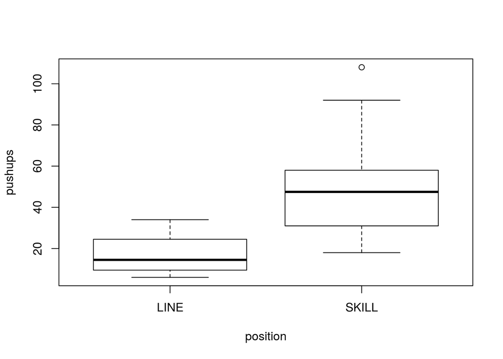

```r
plot(pushups~position,data=players)
```

```r
summary(players)
```

```
##      weight         pushups        position
##  Min.   :151.0   Min.   :  6.00   LINE : 8
##  1st Qu.:181.2   1st Qu.: 24.25   SKILL:22
##  Median :198.0   Median : 36.00
##  Mean   :213.7   Mean   : 41.03
##  3rd Qu.:241.0   3rd Qu.: 51.50
##  Max.   :300.0   Max.   :108.00
```

# Inferential Results

```r
t.test(pushups~position,data=players)
```

```
##
##  Welch Two Sample t-test
##
## data:  pushups by position
## t = -5.4341, df = 27.079, p-value = 9.421e-06
## alternative hypothesis: true difference in means is not equal to 0
## 95 percent confidence interval:
##  -44.91068 -20.29387
## sample estimates:
##  mean in group LINE mean in group SKILL
##            17.12500            49.72727
```

# Discussion and Conclusion